# Лабораторная работа №12

Программирование в командном процессоре ОС UNIX

Липатников Андрей

1032253853@rudn.ru

Российский университет дружбы народов

2026-10-08

# Информация

## Докладчик

- Липатников Андрей
- Студент НКАбд-04-25
- Российский университет дружбы народов
- 1032253853@rudn.ru

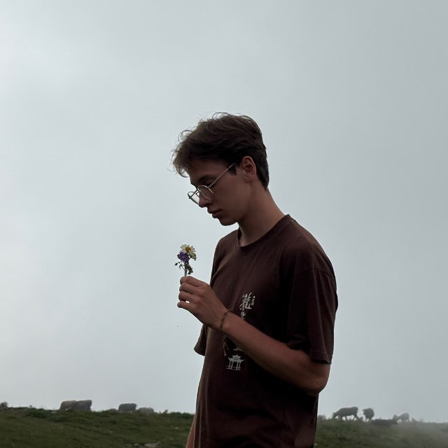

# Вводная часть

## Актуальность

- bash — основной инструмент автоматизации в UNIX/Linux
- скрипты решают задачи резервного копирования, обработки данных, администрирования
- владение переменными, метасимволами и управляющими конструкциями обязательно для администратора

## Объект и предмет исследования

- **Объект**: командный процессор bash
- **Предмет**: переменные, метасимволы, командные файлы, функции, управляющие конструкции

## Цели и задачи

- **Цель**: изучить основы программирования в командном процессоре ОС UNIX; приобрести практические навыки написания командных файлов на bash.
- **Задачи**:
- изучить переменные, метасимволы и экранирование
- освоить командные файлы, функции, передачу параметров
- освоить управляющие конструкции bash
- разработать четыре скрипта по заданиям методички

## Материалы и методы

- ОС: Fedora 41 (Sway), оболочка bash
- инструменты: bash, tar, bzip2, stat, chmod, man
- рабочий каталог: `~/work/study/2025-2026/Операционные системы/os-intro/labs/lab12`
- 4 скрипта, 8 снимков

# Содержание исследования

## Командные оболочки

Таблица 1: Командные оболочки

| Оболочка | Характеристика |
| --- | --- |
| `sh` | Стандартная оболочка UNIX |
| `csh` | C-подобный синтаксис |
| `ksh` | Операторы Борна + удобства C |
| `bash` | Совмещает sh, csh, ksh; POSIX-совместима |

## Переменные и метасимволы

- Присваивание: `var=value`, использование: `$var`
- Стандартные: `HOME`, `IFS`, `MAIL`, `TERM`, `LOGNAME`, `PS1`, `PS2`
- Метасимволы: `*`, `?`, `[c1-c2]`
- Экранирование: `\`, одинарные `'…'`, двойные `"…"`

## Командные файлы и функции

- Скрипт: `chmod +x file.sh`, запуск: `./file.sh`
- Функция:

  ```bash
  function имя { команды; }
  # или
  имя() { команды; }
  ```

- Передача параметров: `$1`, `$2`, …, `$#`, `$@`, `$*`, `$?`, `$$`, `$!`
- `getopts` — разбор флагов командной строки; переменные `OPTARG`, `OPTIND`

## Управляющие конструкции

- `if … then … [elif … then …] [else …] fi`
- `case имя in шаблон) команды;; … esac`
- `for i in … do … done`
- `while условие do … done`
- `until условие do … done`
- `break`, `continue`

## Задание 1. backup.sh

- Резервная копия **самого себя** в `~/backup/`
- Архивация через `tar` + `bzip2` (ключ `-cjf`)
- Имя архива содержит дату и время

```bash
tar -cjf "$BACKUP_DIR/$FILENAME.tar.bz2" "$SELF"
```

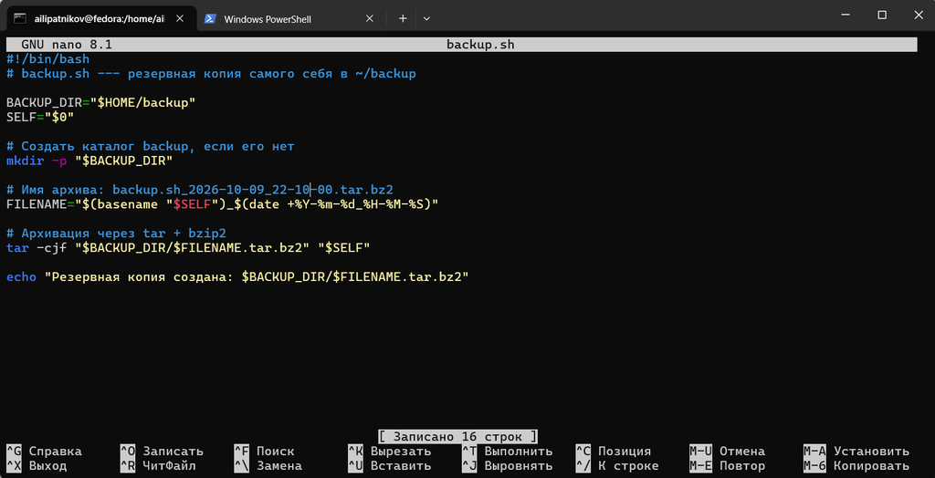

Скрипт backup.sh

## Задание 1. Результат

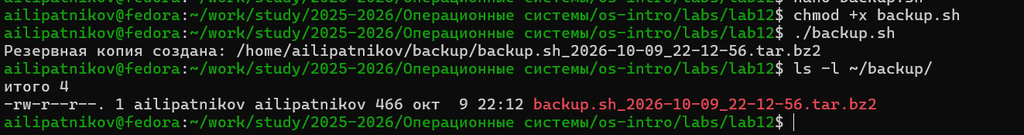

Запуск backup.sh и содержимое ~/backup

- Архив `backup.sh_YYYY-MM-DD_HH-MM-SS.tar.bz2` создан в `~/backup/`

## Задание 2. args.sh

- Вывод **всех** аргументов командной строки
- Обработка **любого** числа аргументов (включая > 10)
- Использованы `$#`, `$@`, `$*`, цикл `for`, арифметика `$((...))`

```bash
for arg in "$@"
do
    echo "  $i: $arg"
    i=$((i + 1))
done
```

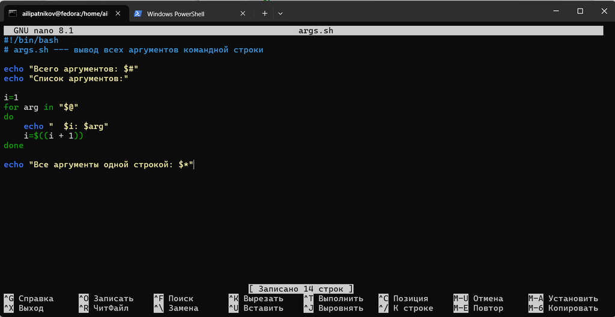

Скрипт args.sh

## Задание 2. Результат

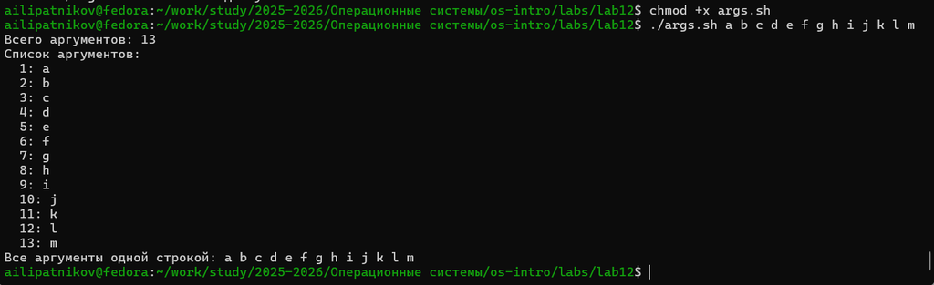

Запуск args.sh с 13 аргументами

- Выведено **13 из 13** аргументов
- Обработка > 10 работает (в отличие от `$1`…`$9`)

## Задание 3. myls.sh

- Аналог `ls` **без** `ls` и `dir`
- Вывод прав через `stat -c "%A"`
- Поддержка скрытых файлов: `.[!.]*`
- Каталоги помечены `/`

```bash
perms=$(stat -c "%A" "$item")
```

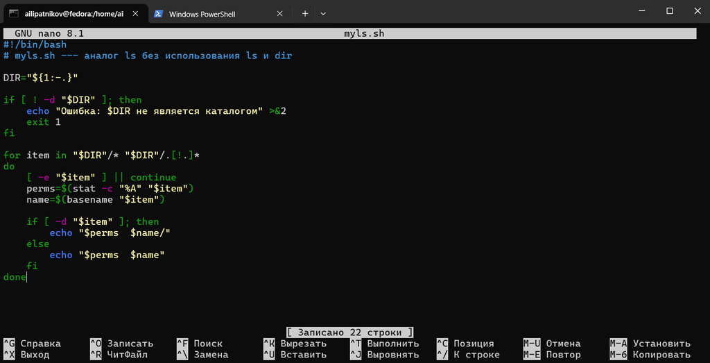

Скрипт myls.sh

## Задание 3. Результат

[figure not shown]

Запуск myls.sh /etc

- Список файлов с правами (аналог `ls -l`)
- Работает для любого каталога, переданного аргументом

## Задание 4. count_ext.sh

- Подсчёт файлов указанного формата в каталоге
- Аргументы: `<формат>` и `<каталог>`
- Проверки: `$#`, `-d`, `-f`

```bash
for item in "$DIR"/*"$FORMAT"
do
    [ -f "$item" ] || continue
    count=$((count + 1))
done
```

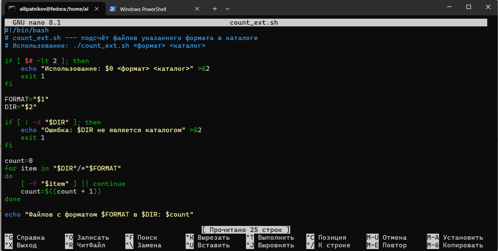

Скрипт count_ext.sh

## Задание 4. Результат

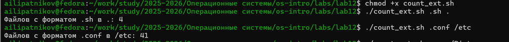

Запуск count_ext.sh

- Подсчитаны файлы нужного формата в указанном каталоге
- Примеры: `./count_ext.sh .sh .`, `./count_ext.sh .conf /etc`

# Результаты

## Полученные результаты

Таблица 2: Сводка результатов

| Задание | Файл | Результат |
| --- | --- | --- |
| 1 | `backup.sh` | Архив в `~/backup/` |
| 2 | `args.sh` | Вывод 13 из 13 аргументов |
| 3 | `myls.sh` | Аналог `ls -l` |
| 4 | `count_ext.sh` | Подсчёт файлов по формату |

## Ключевые конструкции bash

Таблица 3: Ключевые конструкции

| Элемент | Пример |
| --- | --- |
| Переменная | `var=value`, `$var` |
| Метасимвол | `*`, `?`, `[a-z]` |
| Экранирование | `\*`, `'a*b'` |
| Условие | `if [ -d "$dir" ]; then …` |
| Цикл | `for i in "$@"; do … done` |
| Функция | `f() { … }` |

# Заключение

## Главный вывод

bash предоставляет полный набор инструментов для автоматизации: переменные, метасимволы, командные файлы, функции, управляющие конструкции. Разработанные скрипты (резервное копирование, обработка аргументов, аналог `ls`, подсчёт файлов) демонстрируют применимость bash для задач администрирования и обработки данных в UNIX/Linux.